# Лабораторная работа №2

Операционные системы

Терещенкова М.В.

Российский университет дружбы народов, Москва, Россия

07 марта 2025

# Цель работы

Изучить идеологию и применение средств контроля версий;освоить умения по работе с git.

# Задание

1. Создать базовую конфигурацию для работы с git
2. Создать ключ SSH
3. Создать ключ GPG
4. Настроить подписи Git
5. Заргеистрироваться на GitHub
6. Создать локальный каталог для выполнения заданий по предмету.

# Теоретическое введение

**Примеры использования git**

Система контроля версий Git представляет собой набор программ командной строки. Доступ к ним можно получить из терминала посредством ввода команды git с различными опциями.

Благодаря тому, что Git является распределённой системой контроля версий, резервную копию локального хранилища можно сделать простым копированием или архивацией.

## Выполнение лабораторной работы

**Создание ключа SSH**

Создаю ключ ssh размером 4096 бит по алгоритму rsa.

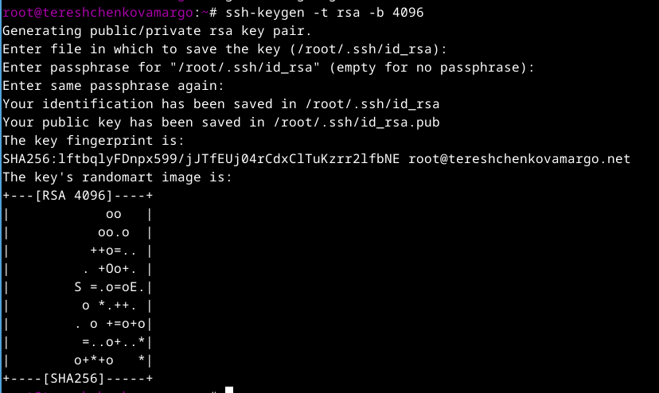

Создание ключа ssh по алгоритму rsa

## Выполнение лабораторной работы

Создаю ключ ssh по алгоритму ed25519

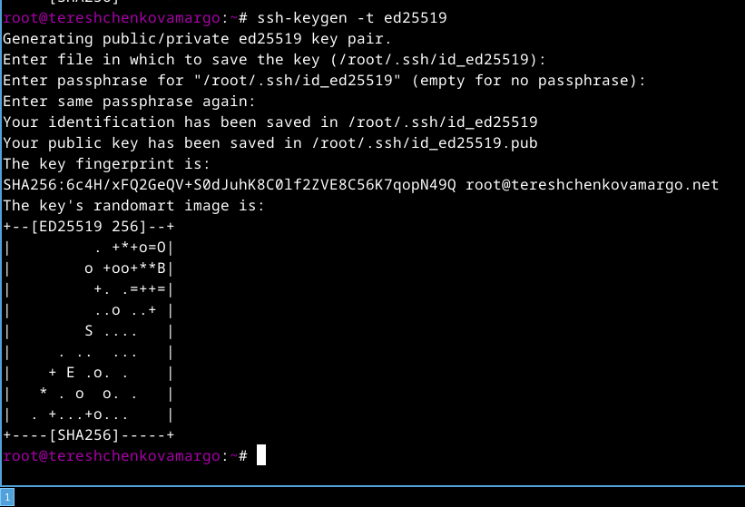

Создание ключа ssh по алгоритму ed25519

## Выполнение лабораторной работы

**Создание ключей pgp**

Генерируем ключ.Из предложенных опций выбираю:тип RSA and RSA; размер 4096;выбераю срок действия; значение по умолчанию — 0 (срок действия не истекает никогда). Также ввожу своё имя и корпоративную почту.

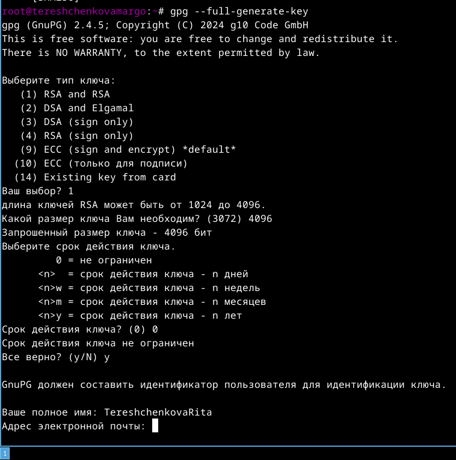

Создание ключа pgp

## Выполнение лабораторной работы

**Настройка gh**

Авторизовываюсь с помощью команды: **gh auth login** и отвечаю на вопросы утилиты.

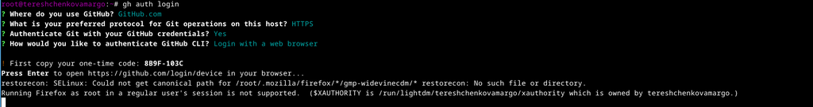

Авторизация gh

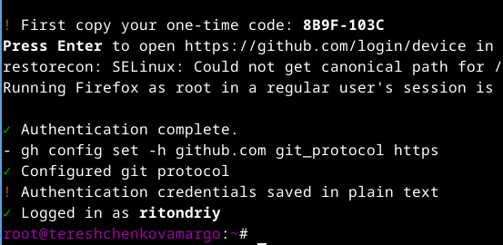

Успешная авторизация

## Выполнение лабораторной работы

**Создание репозитория курса на основе шаблона**

Сначала создаю директорию, перехожу в только что созданную директорию “Операционные системы”, создаю репозиторий на основе шаблона репозитория, клонирую репозиторий к себе в директорию.

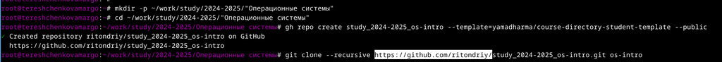

Создание репозитория

# Выводы

Изучила идеологию и применение средств контроля версий;освоила умения по работе с git.